# Covid-19 and Masks

#### Look at linear regression model again with this final form of dataset containing only the two treatment groups

```r
#This shows fit1 has 25% r-sq on the dataset reduced by date and mask compliance of never or alwys; this suggests there may be a difference in low compliance and high compliance; we may have to look at multiple regression using lub_date, *_rate, and categorical of low or high compliance if we decide to produce a model to predict rate upon mask usage of never or always.

fit1 <- lm(newcases_rate ~ lub_date, data = covidmasks)
summary(fit1)
```

```
##
## Call:
## lm(formula = newcases_rate ~ lub_date, data = covidmasks)
##
## Residuals:
##       Min        1Q    Median        3Q       Max
## -0.047242 -0.013407 -0.002713  0.006094  0.259984
##
## Coefficients:
##               Estimate Std. Error t value Pr(>|t|)
## (Intercept) -4.805e+00  1.090e-02  -440.6   <2e-16 ***
## lub_date     2.609e-04  5.893e-07   442.8   <2e-16 ***
## ---
## Signif. codes:  0 '***' 0.001 '**' 0.01 '*' 0.05 '.' 0.1 ' ' 1
##
## Residual standard error: 0.0236 on 574801 degrees of freedom
## Multiple R-squared:  0.2543, Adjusted R-squared:  0.2543
## F-statistic: 1.961e+05 on 1 and 574801 DF,  p-value: < 2.2e-16
```

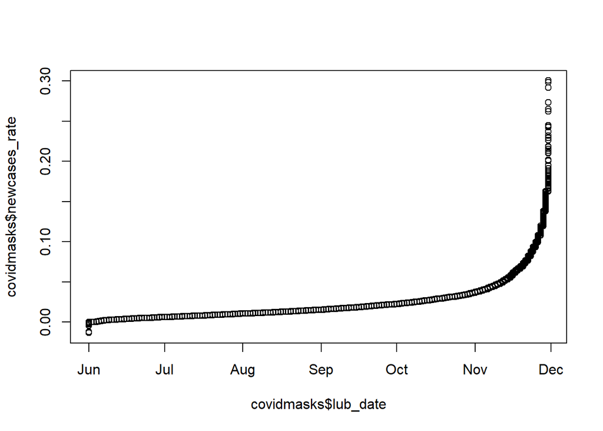

```r
qqplot(covidmasks$lub_date, covidmasks$newcases_rate)
```

#### Scatterplot for the two groups is as follows with color: light blue for compliance = always; dark blue for non-compliance = never. This also hints there may be something happening with level of mask wearing specifically

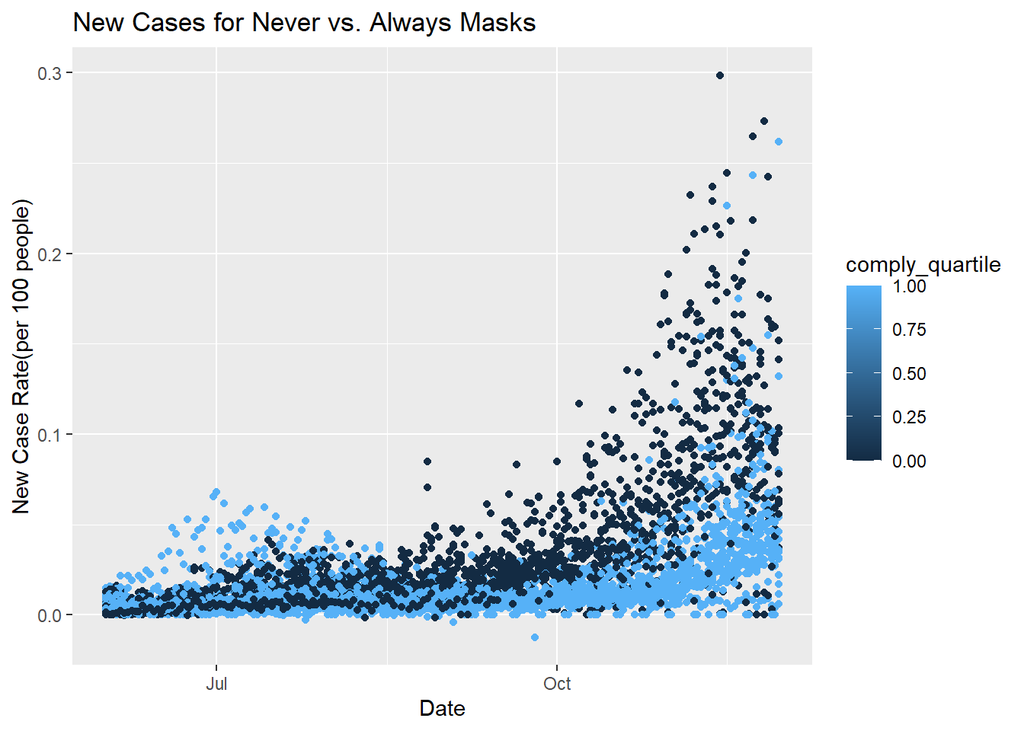

```r
p1 <- covidmasks %>%
   filter(comply_quartile != 99) %>%
  ggplot() +
  geom_point(aes(x = lub_date, y = newcases_rate, color = comply_quartile)) +
xlab("Date") +
ylab("New Case Rate(per 100 people)") +
ggtitle("New Cases for Never vs. Always Masks")

p2 <- covidmasks %>%
  filter(comply_quartile != 99) %>%
  ggplot() +
  geom_point(aes(x = lub_date, y = newdeaths_rate, color = comply_quartile)) +
  xlab("Date") +
  ylab("New Death Rate(per 100 people)") +
  ggtitle("New Deaths for Never vs. Always Masks")


p1
```

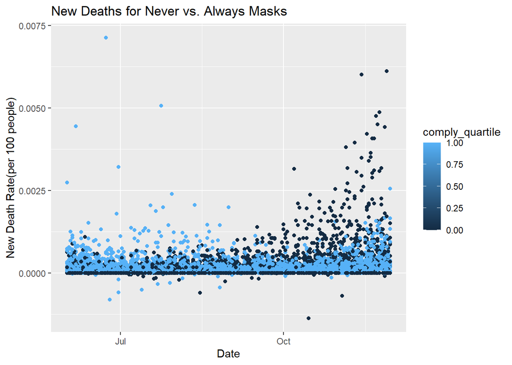

```r
p2
```

##### compare newcases_rate and newdeaths_rate following these implementations

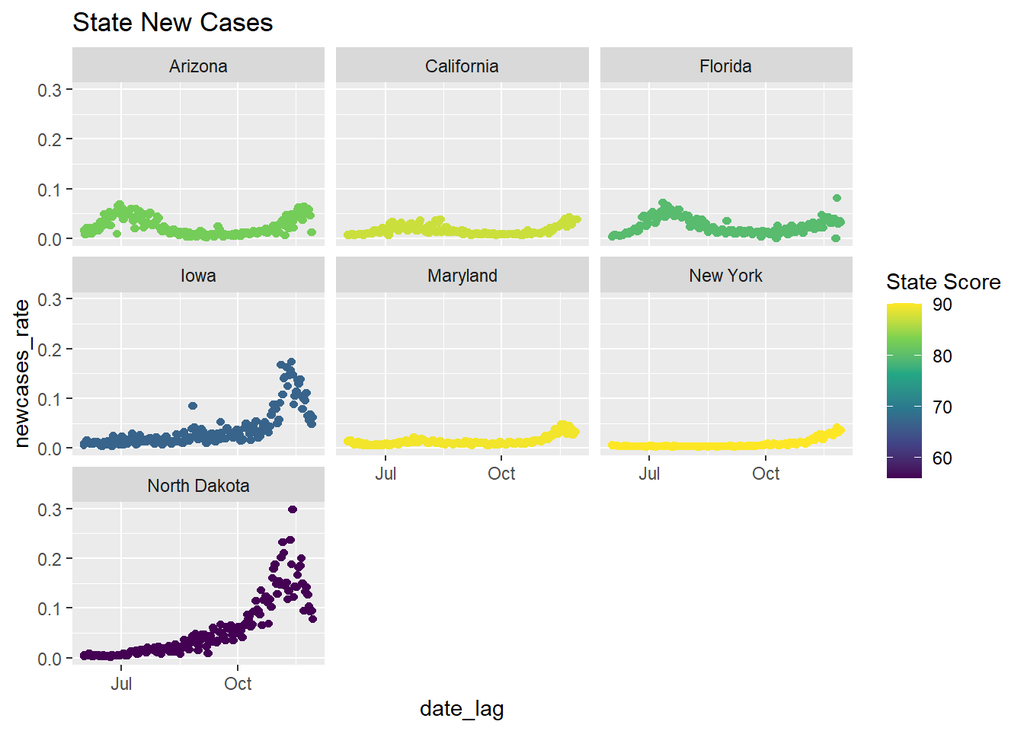

```r
p3 <- covidrep7 %>%
  group_by(regionname) %>%
  summarize(regionname, lub_date, date_lag = lag(lub_date, 28), newcases_rate, st_score) %>%
  ggplot() +
  geom_point(aes(x = date_lag, y = newcases_rate, color = st_score)) + scale_color_viridis_c(name = "State Score") +
  facet_wrap(regionname~.) +
  ggtitle("State New Cases")
p3
```

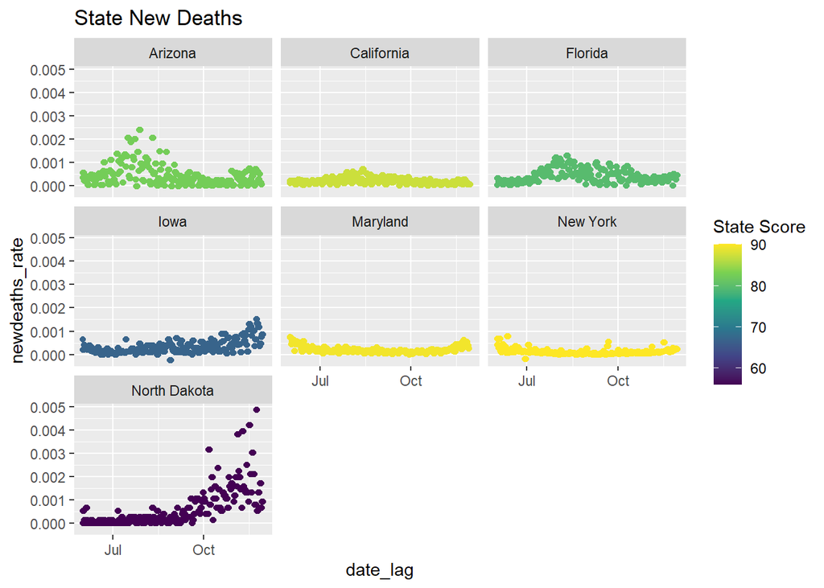

```r
p4 <- covidrep7 %>%
  group_by(regionname) %>%
  summarize(regionname, lub_date, date_lag = lag(lub_date, 28), newdeaths_rate, st_score) %>%
  ggplot() +
  geom_point(aes(x = date_lag, y = newdeaths_rate, color = st_score)) + scale_color_viridis_c(name = "State Score") +
  facet_wrap(regionname~.) +
  ggtitle("State New Deaths")
p4
```

#### Let’s look at the 4 plots of the 2 categories of compliance with in both cases and deaths

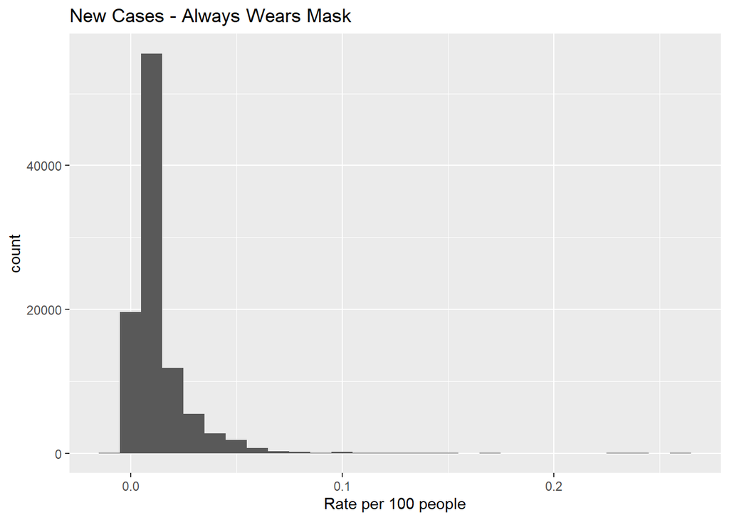

```r
covidmasks %>%
  filter(comply_quartile == 1) %>%
  ggplot() +
  geom_histogram(aes(x = newcases_rate), binwidth = .01) +
  ggtitle("New Cases - Always Wears Mask") +
  xlab("Rate per 100 people")
```

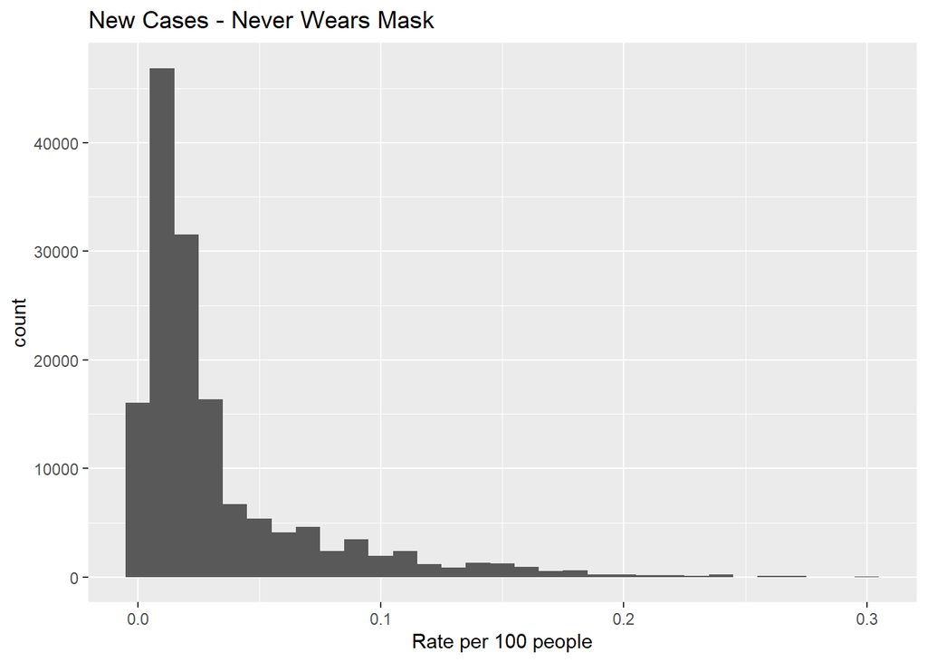

```r
covidmasks %>%
  filter(comply_quartile == 0) %>%
  ggplot() +
  geom_histogram(aes(x = newcases_rate), binwidth = .01) +
  ggtitle("New Cases - Never Wears Mask") +
  xlab("Rate per 100 people")
```

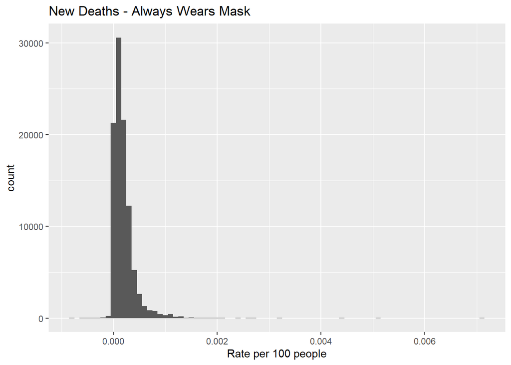

```r
covidmasks %>%
  filter(comply_quartile == 1) %>%
  ggplot() +
  geom_histogram(aes(x = newdeaths_rate), binwidth = .0001) +
  ggtitle("New Deaths - Always Wears Mask") +
  xlab("Rate per 100 people")
```

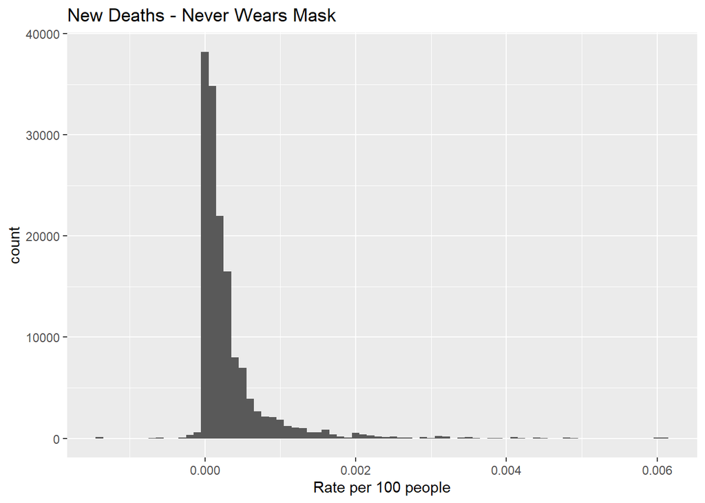

```r
covidmasks %>%
  filter(comply_quartile == 0) %>%
  ggplot() +
  geom_histogram(aes(x = newdeaths_rate), binwidth = .0001) +
  ggtitle("New Deaths - Never Wears Mask") +
  xlab("Rate per 100 people")
```